# Tema 08: Datos Cuantitativos Agrupados

Alonso Pizarro Lagunas

12/11/2021

# Agrupación de datos cuantitativos

## Cómo agrupamos los datos

- Definimos el número de los intervalos
- Decidir la amplitud de los intervalos
- Acumular los exctremos de los intervalos
- Calcular el valor represenytativo de cada intervalo, o marca de clase

### Número de clases

- Establecer el número de clases según la regla de la raíz cuadrada que consiste en tomar la parte entera de la raiz del número de obs
  $$k= \lceil\sqrt n\rceil$$
  .
- Por otro lado, con la **regla de Sturges**
  $$k = \lceil1+ \log_{2}(n)\rceil$$
- Con la **regla de Scott** se determina la amplitud teórica $A_{s} = 3.5 \cdot\tilde{s} \cdot n^{-\frac{1}{3}}$ donde $\tilde{s}$ es la desviación estándar muestral. Luego se sigue que el número de clases queda
  $$k =\bigg\lceil{\frac{max(x)-min(x)}{A_{s}}}\bigg\rceil$$
- La **regla de Freedman-Diaconis** determina una amplitud teórica de las clases $A_{FD}=2 \cdot (Q_{0.75} - Q_{0.25})\cdot n^{-\frac{1}{3}}$, de esta manera el número de clases, que dependen del primer y tercer cuartil, queda:
  $$k =\bigg\lceil{\frac{max(x)-min(x)}{A_{FD}}}\bigg\rceil$$

### Decidiendo la amplitud

- Una vez que se determina *k*, hay que decidir su amplitud. En general, o por defecto, la amplitud de todos los intervalos serán iguales.

### Extremos de un intervalo

- Los intervalos son cerrados por la izquierda, pero abiertos por la derecha. $[L_1,L2),[L_2,L_3),...,[L_k,L_{k+1})$
- $L_i$ denota los extremos de los intervalos.
  $$L_1 = min(x) - \frac{1}{2} \cdot precisión$$

### Marca de clase

- La marca de clase es una valor, $X_i$, de cada intervalo $[L_i, L_{i+1})$ que se utiliza para identificar la clase.
  $$X_i=\frac{L_i+L_{i+1}}{2}$$

## Ejercicio

```r
cangrejos = read.table("../../data/datacrab.txt", header = TRUE)
str(cangrejos)
```

```
## 'data.frame':    173 obs. of  6 variables:
##  $ input : int  1 2 3 4 5 6 7 8 9 10 ...
##  $ color : int  3 4 2 4 4 3 2 4 3 4 ...
##  $ spine : int  3 3 1 3 3 3 1 2 1 3 ...
##  $ width : num  28.3 22.5 26 24.8 26 23.8 26.5 24.7 23.7 25.6 ...
##  $ satell: int  8 0 9 0 4 0 0 0 0 0 ...
##  $ weight: int  3050 1550 2300 2100 2600 2100 2350 1900 1950 2150 ...
```

```r
cw = cangrejos$width

# Calculando el número de clases

n = length(cw)
k1 = ceiling(sqrt(n))
k1
```

```
## [1] 14
```

```r
# Regla de Sturges

k2 = ceiling(1+log(n,2))
k2
```

```
## [1] 9
```

```r
nclass.Sturges(cw)
```

```
## [1] 9
```

```r
# Regla de Scott

As = 3.5 * sd(cw)*n^(-1/3)  # amplitud teória
k3 = ceiling((max(cw)-min(cw))/As)
k3
```

```
## [1] 10
```

```r
nclass.scott(cw)
```

```
## [1] 10
```

```r
# Regla de Freedman-Diaconis


Afd = 2* IQR(cw)*n^(-1/3)
k4 = ceiling((max(cw)-min(cw))/Afd)
k4
```

```
## [1] 13
```

```r
nclass.FD(cw)
```

```
## [1] 13
```

```r
# Amplitud de los intervalos

A = diff(range(cw))/k3
A = 1.3 # la precisión se ajusta a los datos en una unidad

L1 = min(cw)-1/2 * 0.1

# Los intervalos se construyen a partir
L = L1 + A*(0:10)
L
```

```
##  [1] 20.95 22.25 23.55 24.85 26.15 27.45 28.75 30.05 31.35 32.65 33.95
```

```r
# Las Marcas de clases se construyen como Xi+1 = xi + A donde xi = (li + li+1)/2

x1 = (L[1] +L[2])/2


X = x1 + A*(0:9)
X
```

```
##  [1] 21.6 22.9 24.2 25.5 26.8 28.1 29.4 30.7 32.0 33.3
```

#### La función Cut

```r
petals = iris$Petal.Length
petals
```

```
##   [1] 1.4 1.4 1.3 1.5 1.4 1.7 1.4 1.5 1.4 1.5 1.5 1.6 1.4 1.1 1.2 1.5 1.3 1.4
##  [19] 1.7 1.5 1.7 1.5 1.0 1.7 1.9 1.6 1.6 1.5 1.4 1.6 1.6 1.5 1.5 1.4 1.5 1.2
##  [37] 1.3 1.4 1.3 1.5 1.3 1.3 1.3 1.6 1.9 1.4 1.6 1.4 1.5 1.4 4.7 4.5 4.9 4.0
##  [55] 4.6 4.5 4.7 3.3 4.6 3.9 3.5 4.2 4.0 4.7 3.6 4.4 4.5 4.1 4.5 3.9 4.8 4.0
##  [73] 4.9 4.7 4.3 4.4 4.8 5.0 4.5 3.5 3.8 3.7 3.9 5.1 4.5 4.5 4.7 4.4 4.1 4.0
##  [91] 4.4 4.6 4.0 3.3 4.2 4.2 4.2 4.3 3.0 4.1 6.0 5.1 5.9 5.6 5.8 6.6 4.5 6.3
## [109] 5.8 6.1 5.1 5.3 5.5 5.0 5.1 5.3 5.5 6.7 6.9 5.0 5.7 4.9 6.7 4.9 5.7 6.0
## [127] 4.8 4.9 5.6 5.8 6.1 6.4 5.6 5.1 5.6 6.1 5.6 5.5 4.8 5.4 5.6 5.1 5.1 5.9
## [145] 5.7 5.2 5.0 5.2 5.4 5.1
```

```r
irisDF = iris

irisDF$dv1 = cut(petals, breaks = 5, right = FALSE)  # sin especificar regla
irisDF$dv2 = cut(petals, breaks = ceiling(sqrt(length(petals))), right = FALSE)
irisDF$dv3 = cut(petals, breaks = c(1,2,3,4,5,6,7), right = FALSE)
irisDF$dv4 = cut(petals, breaks = 5, right = FALSE, labels = FALSE) # Toma con ref el num de los intervalos.
irisDF$dv5 = cut(petals, breaks = 5, right = FALSE, labels = c("Peq","Norm","Gran","XGran","Gigan"))
irisDF[,c(3,5:10)]
```

```
##     Petal.Length    Species          dv1          dv2   dv3 dv4   dv5
## 1            1.4     setosa [0.994,2.18) [0.994,1.45) [1,2)   1   Peq
## 2            1.4     setosa [0.994,2.18) [0.994,1.45) [1,2)   1   Peq
## 3            1.3     setosa [0.994,2.18) [0.994,1.45) [1,2)   1   Peq
## 4            1.5     setosa [0.994,2.18)  [1.45,1.91) [1,2)   1   Peq
## 5            1.4     setosa [0.994,2.18) [0.994,1.45) [1,2)   1   Peq
## 6            1.7     setosa [0.994,2.18)  [1.45,1.91) [1,2)   1   Peq
## 7            1.4     setosa [0.994,2.18) [0.994,1.45) [1,2)   1   Peq
## 8            1.5     setosa [0.994,2.18)  [1.45,1.91) [1,2)   1   Peq
## 9            1.4     setosa [0.994,2.18) [0.994,1.45) [1,2)   1   Peq
## 10           1.5     setosa [0.994,2.18)  [1.45,1.91) [1,2)   1   Peq
## 11           1.5     setosa [0.994,2.18)  [1.45,1.91) [1,2)   1   Peq
## 12           1.6     setosa [0.994,2.18)  [1.45,1.91) [1,2)   1   Peq
## 13           1.4     setosa [0.994,2.18) [0.994,1.45) [1,2)   1   Peq
## 14           1.1     setosa [0.994,2.18) [0.994,1.45) [1,2)   1   Peq
```

[output cut: 136 more lines]

### Agrupando datos

- Tabla de frecuencias absolutas y relativas con datos agrupados
- Diferentes codificación de la variable cuantitativa

```r
# Generando una función

TablaFrecs = function(x,k,A,p){
  L = min(x) - 1/2 * p + A*(0:k)
  x_cut = cut(x, breaks = L, right = FALSE)
  intervals = levels(x_cut)
  mc = (L[1]+L[2])/2 + A*(0:(k-1))
  Fr.abs = as.vector(table(x_cut))
  Fr.rel = round(Fr.abs/length(x),4)
  Fr.cum.abs = cumsum(Fr.abs)
  Fr.cum.rel = cumsum(Fr.rel)
  tabla = data.frame(intervals, mc, Fr.abs, Fr.cum.abs, Fr.rel, Fr.cum.rel)
  tabla
}
```

La tabla de frecuencias de la longitud de los pétalos de *Iris* es:

```r
petals
```

```
##   [1] 1.4 1.4 1.3 1.5 1.4 1.7 1.4 1.5 1.4 1.5 1.5 1.6 1.4 1.1 1.2 1.5 1.3 1.4
##  [19] 1.7 1.5 1.7 1.5 1.0 1.7 1.9 1.6 1.6 1.5 1.4 1.6 1.6 1.5 1.5 1.4 1.5 1.2
##  [37] 1.3 1.4 1.3 1.5 1.3 1.3 1.3 1.6 1.9 1.4 1.6 1.4 1.5 1.4 4.7 4.5 4.9 4.0
##  [55] 4.6 4.5 4.7 3.3 4.6 3.9 3.5 4.2 4.0 4.7 3.6 4.4 4.5 4.1 4.5 3.9 4.8 4.0
##  [73] 4.9 4.7 4.3 4.4 4.8 5.0 4.5 3.5 3.8 3.7 3.9 5.1 4.5 4.5 4.7 4.4 4.1 4.0
##  [91] 4.4 4.6 4.0 3.3 4.2 4.2 4.2 4.3 3.0 4.1 6.0 5.1 5.9 5.6 5.8 6.6 4.5 6.3
## [109] 5.8 6.1 5.1 5.3 5.5 5.0 5.1 5.3 5.5 6.7 6.9 5.0 5.7 4.9 6.7 4.9 5.7 6.0
## [127] 4.8 4.9 5.6 5.8 6.1 6.4 5.6 5.1 5.6 6.1 5.6 5.5 4.8 5.4 5.6 5.1 5.1 5.9
## [145] 5.7 5.2 5.0 5.2 5.4 5.1
```

```r
TablaFrecs(petals, k = 6, A = 1, p = 0.1)
```

```
##     intervals   mc Fr.abs Fr.cum.abs Fr.rel Fr.cum.rel
## 1 [0.95,1.95) 1.45     50         50 0.3333     0.3333
## 2 [1.95,2.95) 2.45      0         50 0.0000     0.3333
## 3 [2.95,3.95) 3.45     11         61 0.0733     0.4066
## 4 [3.95,4.95) 4.45     43        104 0.2867     0.6933
## 5 [4.95,5.95) 5.45     35        139 0.2333     0.9266
## 6 [5.95,6.95) 6.45     11        150 0.0733     0.9999
```

Utilizando la tabla de los cangrejos echaremos manos a nuestra función de frecuencias de datso agrupados.

```r
tabla = TablaFrecs(cangrejos$width, k = 10, A = 1.3 , p = 0.1 )
```

# Estadísticos para datos agrupados

```r
TOT = tabla$Fr.cum.abs[10]
TOT
```

```
## [1] 173
```

```r
anchura.media = round(sum(tabla$mc * tabla$Fr.abs)/TOT,3)
anchura.media
```

```
## [1] 26.312
```

- Por tanto, la anchura media para datos agrupados es *26.312*
- La *varianza* para datos agrupados la podemos definir como $s^2=\frac{\sum_{j=1}^k n_j X_j^2}{n}-\bar x^2$

```r
varianza.media = round(sum(tabla$mc^2 * tabla$Fr.abs)/TOT - anchura.media^2,3)
varianza.media
```

```
## [1] 4.476
```

- La varianza será *4.476*
- La desviación típica se calcula aplicando la raíz a la varianza para datso agrupados

```r
anchura.dt = round(sqrt(varianza.media),3)
anchura.dt
```

```
## [1] 2.116
```

- La *desviación* típica de las anchura de los cangrejos correspondientes es *2.116*
- Ahora vamos con el interval modal

```r
I.modal = tabla$intervals[which(tabla$Fr.abs== max(tabla$Fr.abs))]
I.modal
```

```
## [1] "[24.9,26.1)"
```

- El intervalo modfal para este conjuntio de datos de anchuras corresponde a *[24.9,26.1)*
- De fomra similar podemos agregar el *intervalo crítico* para la mediana.

```r
I.critic = tabla$intervals[which(tabla$Fr.cum.rel >= 0.5)]
I.critic
```

```
## [1] "[24.9,26.1)" "[26.1,27.4)" "[27.4,28.8)" "[28.8,30)"   "[30,31.4)"
## [6] "[31.4,32.6)" "[32.6,34)"
```

- El el intervalo donde la distribución de datos comprende o supera al 50% de los datos es [24.9,26.1)
- Estimación de la *mediana* de los datos reales

```r
L
```

```
##  [1] 20.95 22.25 23.55 24.85 26.15 27.45 28.75 30.05 31.35 32.65 33.95
```

```r
n = TOT
Lc= L[4]  # límite inferior
Lc.pos = L[5]
Ac = L[5] - L[4] # amplitu del intervalo
Nc.ant = tabla$Fr.cum.abs[3] # FRec acumulada del anterior (respecto al 4)
nc = tabla$Fr.abs[4]
M = Lc+Ac*((n/2)-Nc.ant)/nc   # formula para la mediana
M # aproximaicón de la mediana
```

```
## [1] 26.13523
```

```r
median(cw) # todos los datos
```

```
## [1] 26.1
```

#### Hacer tarea video 143

# Histogramas

- Mejor manera de representar datos agrupados. Barras juntas, los datos son cuantritaticos continuos.
- El diagrama de barras se utiliza para cualidades, factores. Construidos con barras separadas.

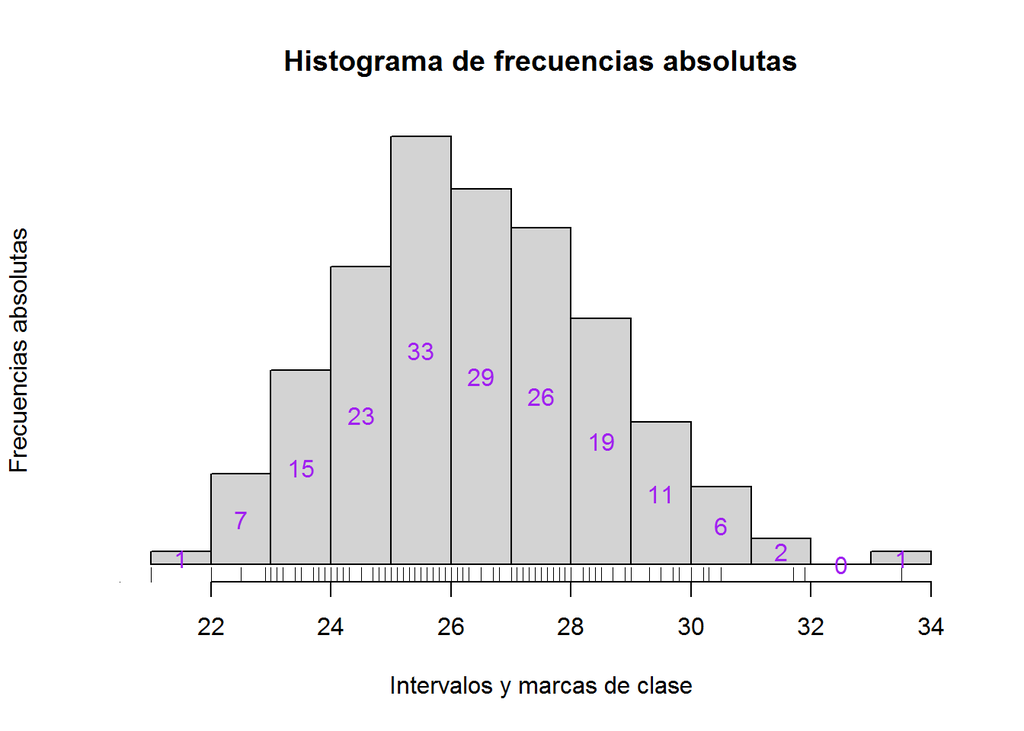

```r
# Creando una función para graficar histogramas


histAbs = function(x,L){

  h = hist(x, breaks = L, right = FALSE, freq = FALSE,
           yaxt= "n", col = "lightgray",
           main = "Histograma de frecuencias absolutas",
           xlab = "Intervalos y marcas de clase", ylab = "Frecuencias absolutas")
  axis(1,at=L)
  rug(x)
  jitter(x)
  text(h$mids, h$density/2, labels = h$counts, col ="purple") # aquí ponemos el número en cada barra
}

histAbs(cangrejos$width, 9)
```

```r
nclass.Sturges(cangrejos$width)
```

```
## [1] 9
```

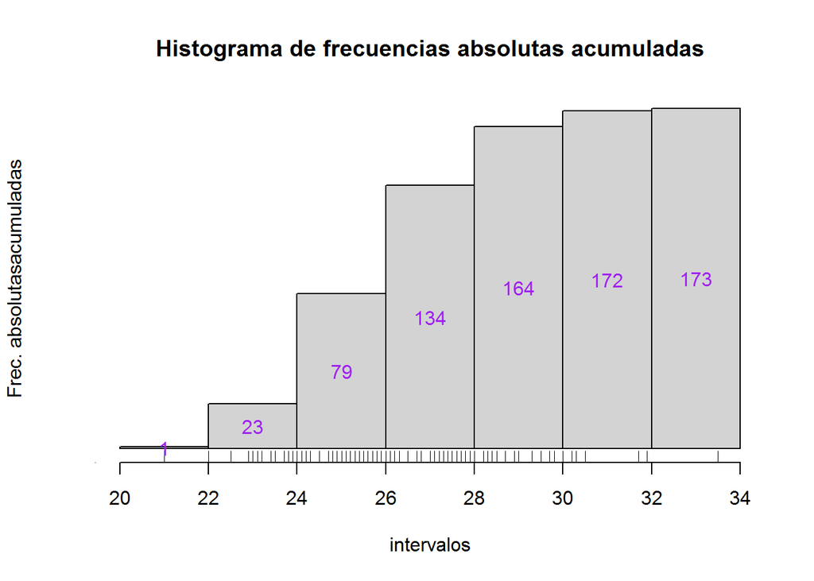

```r
histAbsCum = function(x,L){
    h = hist(x, breaks = L, right = FALSE, plot = FALSE)
    h$density = cumsum(h$density)
    plot(h, freq = FALSE, yaxt = "n", col = "lightgray",
         main = "Histograma de frecuencias absolutas acumuladas",
         xlab = "intervalos",
         ylab = "Frec. absolutasacumuladas")
    axis(1, at = L)
    rug(x)
    text(h$mids, h$density/2, labels = cumsum(h$counts), col ="purple")
}

histAbsCum(cangrejos$width, 6)
```